# Praca domowa nr 2

Tomaszewska Paulina

Zrealizowane na podstawie pracy studenta: Agata Paldyna

Wprowadzone modyfikacje: 1. W oryginalnym rozwiązaniu usunięto jeden rekord, ponieważ skoczek (Zografski) nie miał oceny za drugi skok (został zdyskwalifikowany po pierwszej serii). Niemniej z racji na dobry skok w pierwszej serii zdobył wystarczająco dużo punktów, aby awansować do rundy finałowej. Zawsze w drugiej serii uczestniczy 30 zakwalifikowanych skoczków, dlatego usunięcie jednego rekordu zniekształca rzeczywistość.Dyskwalifikacja po pierwszej serii powoduje jedynie, że zawodnik dostaje zero punktów za drugi skok. Dlatego też zamieniono wartość oceny za drugi skok z NA na zero, natomiast wartość NA jako całkowitą sumę punktów za dwa skoki zmieniono na wartość punktów uzyskaną w pierwszej serii. Informację o dyskwalifikacji zawodnika zaznaczono w ramach “caption”, a także w ramach labels jako “DS”. 2. Większono liczbę informacji explicite widoczną na wykresie poprzez dodanie etykiet (labels), co umożliwia porówanie rekordów pod wzgledem ilościowym, a nie tylko tak jak poprzednio - jakościowym. Etykiety zostały przedstawione w następujący sposób: dla skoczka, który uzyskał największą liczbę punktów przedstawiono tę liczbę, natomiast dla kolejnych skoczków (z wyjątkiem ostatniego) przedstawiono różnicę między jego wynikiem a wynikiem zwycięzcy. 3. Pastelowe kolory słupków w ramach wykresu kolumnowego zlewały się z szarym tłem, dlatego zmieniłam theme, tak aby tło było białe 4. Dla zwiększenia czytelności wykresu zmieniono paletę barw z pastelowej (“Set3”), na “Paired”, która poprzez “żywsze” kolory bardziej przyciąga wzrok, a także pozwala na łatwiejsze rozróżnienie poszczególnych kategorii. 5. W celu lepszego wyodrębnienia poszczególnych słupków na wykresie (niektóre miały zbliżony kolor) zastosowano obwódki słupków geom_bar(…,color=‘black’) 6. W oryginalnym rozwiązaniu przedstawiono informację jedynie o całkowitej sumie punktów po dwóch seriach, tymczasem ciekawa jest także informacja o punktach zdobytych przez skoczków w każdej z serii. W tym celu stworzono dwa dodatkowe wykresy, które następnie w ramach pakietu patchwork połączono wraz z bazowym w jeden.

### Tworzenie ramki danych

Dane do wykresu zebralam z artykulu znajdujacego sie pod nastepujacym linkiem: https://wspolczesna.pl/skoki-narciarskie-online-ps-inssbruck-seefeld-2019-konkurs-indywidualny-i-druzynowy-kto-wygral-wyniki-25022019/ar/13906968.

```r
Name <- c("Eisenbichler M.", "Geiger K.", "Peier K.", "Kobayashi R.", "Stoch K.",
           "Kraft S.", "Forfang J.", "Johansson R.", "Freitag R.", "Zajc T.",
           "Huber D.", "Kubacki D.", "Aschenwald P.", "Hayboeck M.", "Ammann S.",
           "Prevc P.", "Kobayashi J.", "Klimov E.", "Zyla P.", "Ito D.", "Sato Y.",
           "Koudelka R.", "Jelar Z.", "Fettner M.", "Polasek V.", "Schuler A.",
           "Boyd-Clowes M.", "Learoyd J.", "Stjernen A.", "Zografski V.")
Nationality <- c("GER", "GER", "SUI", "JPN", "POL", "AUT", "NOR", "NOR", "GER",
                   "SLO", "AUT", "POL", "AUT", "AUT", "SUI", "SLO", "JPN", "RUS",
                   "POL", "JPN", "JPN", "CZE", "SLO", "AUT", "CZE", "SUI", "CAN",
                   "FRA", "NOR", "BUL")
Dist1 <- c(131.5, 131.0, 131.0, 133.5, 128.5, 130.0, 132.5, 128.0, 125.5, 127.0, 126.0,
           128.5, 120.0, 122.0, 122.5, 123.5, 116.0, 126.5, 128.5, 119.0, 120.0, 120.5,
           118.5, 117.5, 120.0, 117.5, 117.0, 116.5, 124.5, 117.0)
Dist2 <- c(135.5, 130.5, 129.5, 126.5, 129.5, 126.5, 125.5, 129.0, 129.5, 124.0, 125.5,
           125.5, 128.0, 125.5, 126.0, 122.0, 132.0, 121.0, 121.0, 126.0, 124.0, 120.5,
           121.0, 122.5, 117.5, 119.0, 118.5, 116.5, 102.0, NA)
Total <- c(279.4, 267.3, 266.1, 262.0, 259.4, 256.1, 250.9, 248.9, 248.7, 245.5, 242.0,
          240.2, 239.9, 233.7, 230.6, 230.5, 230.0, 229.1, 228.7, 225.7, 221.4, 220.1,
          219.8, 219.0, 218.2, 212.6, 212.1, 205.9, 185.5, NA)

Dist2[length(Dist2)]=0
Total[length(Total)]=Dist1[length(Dist1)]

MS2019_scores <- data.frame(Name, Nationality, Dist1, Dist2, Total)
```

### Wykres

Zdobyte dane ilustruje ponizszy wykres.

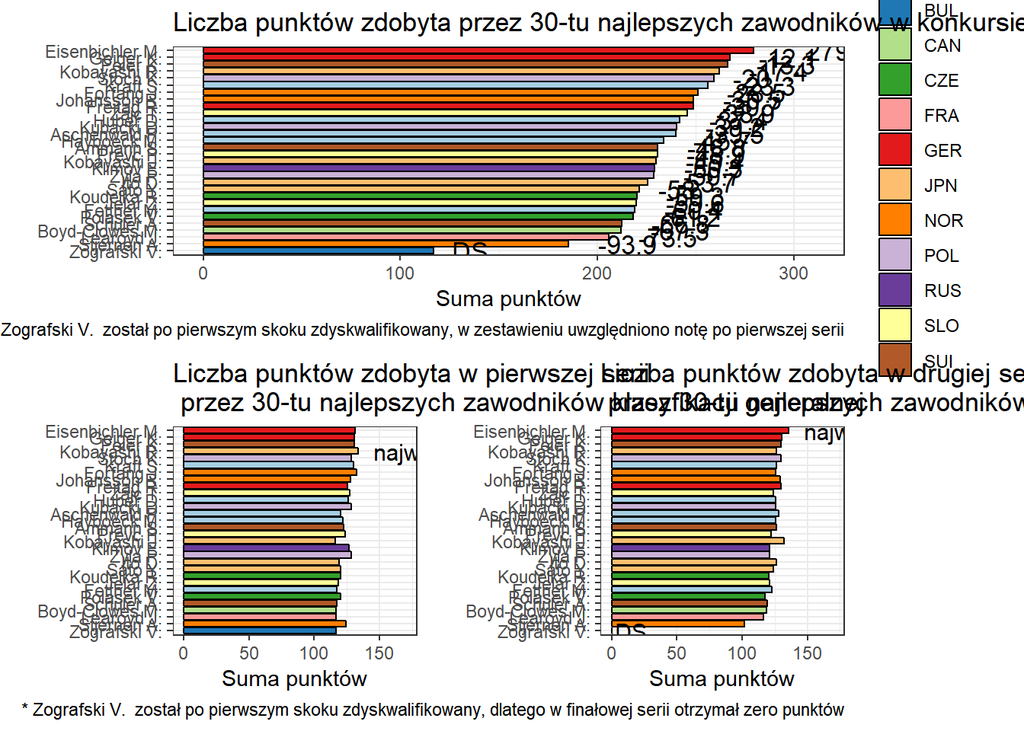

```r
library(ggplot2)
library(RColorBrewer)

diff_punktowa=max(Total)-Total
diff_punktowa[1]=paste0(max(Total), "pkt.")
for (i in 3:length(diff_punktowa)-1)
{
  diff_punktowa[i]=paste0("-", diff_punktowa[i])
}

diff_punktowa[30]="DS"

p1<-ggplot(MS2019_scores, aes(x = reorder(Name, Total), y = Total, fill = Nationality, label=diff_punktowa)) +geom_bar(stat = "identity", color='black') + coord_flip() + ylim(0, 310) +
  scale_fill_brewer(palette = "Paired" , name = "Narodowość") +
  ggtitle("Liczba punktów zdobyta przez 30-tu najlepszych zawodników w konkursie indywidualnym w ramach Mistrzostw Świata 2019 w skokach narciarskich") +xlab("") + ylab("Suma punktów")+theme_bw()+ geom_text(hjust=-0.5,size=4.5)+
  labs(caption = paste("*", Name[length(Name)]," został po pierwszym skoku zdyskwalifikowany, w zestawieniu uwzględniono notę po pierwszej serii") )


max_value<-function (data_vector){
labels_data_vector=vector()
for (i in 1:length(data_vector)){
  labels_data_vector[i]=""
  if (data_vector[i]==max(data_vector)){
    labels_data_vector[i]="najwyższa nota"
  }

}
return (labels_data_vector)
}

label_Dist2=max_value(Dist2)
label_Dist2[30]="DS"

p2<-ggplot(MS2019_scores, aes(x = reorder(Name, Total), y = Dist1, fill = Nationality, label=max_value(Dist1))) +
  geom_bar(stat = "identity", color='black') + coord_flip()  +
  scale_fill_brewer(palette = "Paired" , name = "Narodowość") +geom_text(hjust=-0.1,size=4)+
  ggtitle("Liczba punktów zdobyta w pierwszej serii\n przez 30-tu najlepszych zawodników klasyfikacji generalnej") +xlab("") + ylab("Suma punktów")+theme_bw()+ theme(legend.position = "none")+ylim(0,170)

p3<-ggplot(MS2019_scores, aes(x = reorder(Name, Total), y = Dist2, fill = Nationality, label=label_Dist2)) +
  geom_bar(stat = "identity", color='black') + coord_flip() +
  scale_fill_brewer(palette = "Paired" , name = "Narodowość") +ylim(0,170)+
  ggtitle("Liczba punktów zdobyta w drugiej serii\n przez 30-tu najlepszych zawodników klasyfikacji generalnej")+xlab("") + ylab("Suma punktów")+theme_bw()+theme(legend.position = "none")+ geom_text(hjust=-0.1,size=4)+
labs(caption = paste("*", Name[length(Name)]," został po pierwszym skoku zdyskwalifikowany, dlatego w finałowej serii otrzymał zero punktów") )

p1/(p2+p3)
```